# Applied Machine Learning with R

March 29, 2019

## Evaluating Model Performance

## Measuring performance for regression

- **Mean Absolute Error (MAE)** is the sum of the absolute differences between predictions and actual values;

\[ \text{MAE} = \frac{1}{N} \sum_{i = 1}^N |y_i - \hat{y_i}| \]

- **Root Mean Squared Error (RMSE)** is square root of the variance of the residuals;

\[ \text{MSE} = \sum_{i = 1}^N (y_i - \hat{y_i})^2 \]

- Taking the square root of the *MSE* converts the units back to the original units;
- **\(R^2\) (R-Squared)** metric provides an indication of the goodness of fit;

\[ R^2 = 1 - \frac{\sum_{i = 1}^N (y_i - \hat{y_i})^2}{\sum_{i = 1}^N (y_i - \overline{y_i})^2} \]

- This is a value between \(0\) and \(1\).

## Measuring performance for classification

- Until now, we have only examined classification predictions using **actual** and **predicted** classes;
- Most of the models can supply another piece of information: the **probability**;

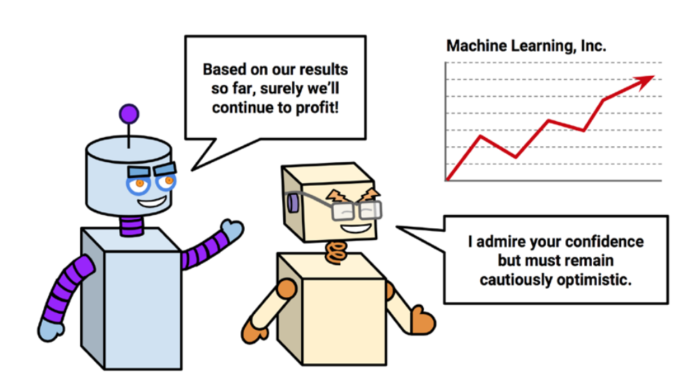

- It is ideal to fit a model:
  - Extremely confident when making correct predictions;
  - Timid in the face of doubt.

## Confusion Matrix

- CM is a performance measurement for machine learning classification problems;
- It is a table with 4 different combinations of predicted and actual values;
- It is extremely useful for measuring **Accuracy**, **Recall**, **Precision**, and **F1-score**.

## Confusion Matrix

## Accuracy

- **Accuracy** is given by

\[ \text{Acc} = \frac{TP + TN}{TP + FP + FN + TN} \]

## Recall

- **Recall** (**Sensitivity**): out of all the actual positive classes, how much we predicted correctly;

\[ \text{Recall} = \frac{TP}{TP + FN} \]

## Precision

- **Precision**: out of all the **predicted** positive classes, how much we predicted correctly;

\[ \text{Precision} = \frac{TP}{TP + FP} \]

## Performance for Skewed Classes

- It is sometimes difficult to tell whether a reduction in error is an improvement of the algorithm;
- For instance: suppose we are predicting a cancer diagnoses where \(0.5\%\) of the examples have cancer;
- We find our learning algorithm has a \(1\%\) error. Sounds very good, right?!
- Suppose an algorithm simply classify every single example as a 0. Which is the error?
- This usually happens with **skewed** classes;
- Using *accuracy* as a performance metric could be misleading;
- For these cases, better use **recall** and **precision**;

## Trade off between Recall and Precision

- Default behavior of every algorithm is to assign an *obs* to a class w-ith the greatest probability;
- In the case of \(K\) classes, this rule is greater than \(1/K\);
- Again, consider the case where we are predicting a cancer diagnoses where 0.5% of the examples have cancer;
- We change our threshold and classify as positive if \(P(x) \gt 0.7\);

\[ \text{Recall} \downarrow \quad \text{Precision} \uparrow \]

- Now, let’s pretend our threshold moved to something as \(P(x) \gt 0.3\); \[ \text{Recall} \uparrow \quad \text{Precision} \downarrow \]
- That is, there is a trade-off between **Recall** and **Precision**;
- But, we want both to be high! What now?

## F1 Score

- One way we can circumvent this issue is to combine *Recall* and *Precision* into a single metric;
- Average? \[ \frac{\text{Recall} + \text{Precision}}{2} \]
- I don’t think so!!
- A better way is to compute the *F Score* (or **F1 score**):

\[ F1 = \frac{2^*\text{Recall}^*\text{Precision}}{\text{Recall} + \text{Precision}} \]

- In order for the **F Score** to be large, both *Precision* and *Recall* must be large;

## Kappa

- **Kappa** statistics adjust *accuracy* by account for the possibility of a correct prediction by chance;
- This is especially important for datasets with severe class imbalance;
- The **Kappa** will only reward the algorithm if it correct more often that this simplistic strategy;
- Kappa values range from \(0\) to \(1\);
- Kappa are calculated as

\[ \kappa = \frac{P(a) - P(e)}{1 - P(e)} \] where:

- \(P(a)\) refers to the proportion of actual agreement (*accuracy*);
- \(P(e)\) refers to the expected agreement between the classifier and the true values, under the assumption chosen at random;

## Kappa

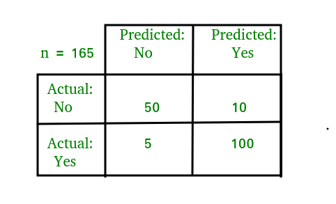

\[ P(a) = \frac{50+100}{50 + 10 + 5 + 100} = 0.909 \]

\[ P(e) = \frac{55}{165}*\frac{60}{165} + \frac{110}{165}*\frac{105}{165} = 0.545 \] \[ \kappa = \frac{0.909 - 0.545}{1 - 0.545} = 0.8 \]

## AUC - ROC curve

- Remember that an algorithm outputs a probability;
- Commonly, a threshold = \(0.5\);
- For each threshold \(\rightarrow\) different *confusion matrix*;
- **Receiver Operator Characteristic** (ROC) curve provides a simple graphic way to summarize;

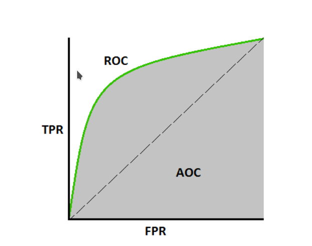

## AUC - ROC curve

- Remember:

\[ \text{TPR} = \frac{TP}{TP + FN} \] \[ \text{FPR} = \frac{FP}{TN + FP} \]

## AUC - ROC curve

- Let’s say we define our threshold as \(0\);

|  | Actual positive | Actual negative |
| --- | --- | --- |
| positive | 4 | 4 |
| negative | 0 | 0 |

\[ \text{TPR} = \frac{4}{4 + 0} = 1 \] \[ \text{FNR} = \frac{4}{4 + 0} = 1 \]

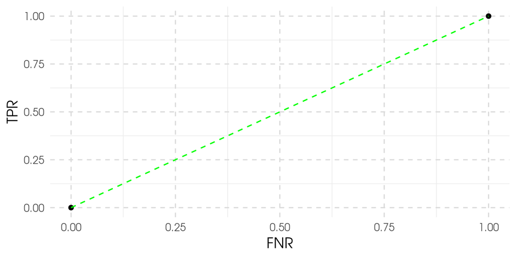

## AUC - ROC curve

- Let’s say we define our threshold as \(0.2\);

|  | Actual positive | Actual negative |
| --- | --- | --- |
| positive | 4 | 3 |
| negative | 0 | 1 |

\[ \text{TPR} = \frac{4}{4 + 0} = 1 \] \[ \text{FNR} = \frac{3}{3 + 1} = 0.75 \]

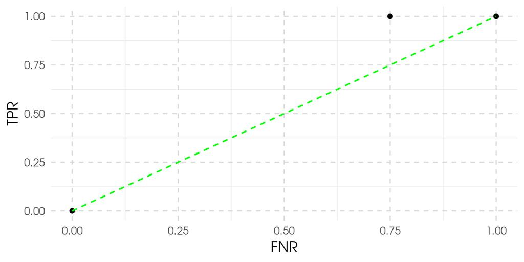

## AUC - ROC curve

- Let’s say we define our threshold as \(0.3\);

|  | Actual positive | Actual negative |
| --- | --- | --- |
| positive | 4 | 2 |
| negative | 0 | 2 |

\[ \text{TPR} = \frac{4}{4 + 0} = 1 \] \[ \text{FNR} = \frac{2}{2 + 2} = 0.5 \]

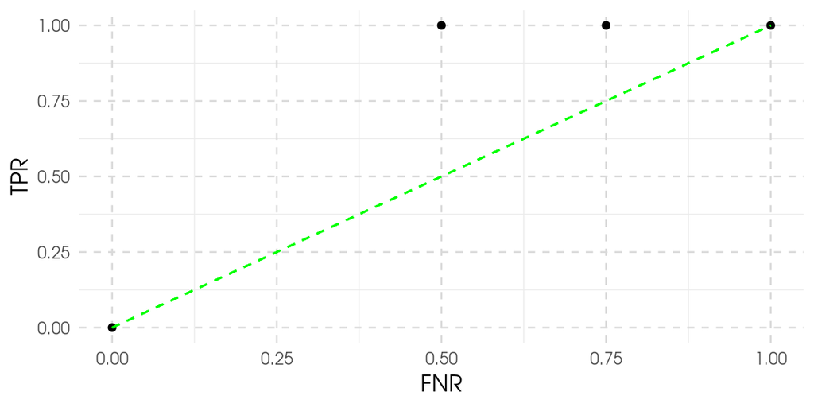

## AUC - ROC curve

- Let’s say we define our threshold as \(0.5\);

|  | Actual positive | Actual negative |
| --- | --- | --- |
| positive | 3 | 1 |
| negative | 1 | 3 |

\[ \text{TPR} = \frac{3}{3 + 1} = 0.75 \] \[ \text{FNR} = \frac{1}{1 + 3} = 0.25 \]

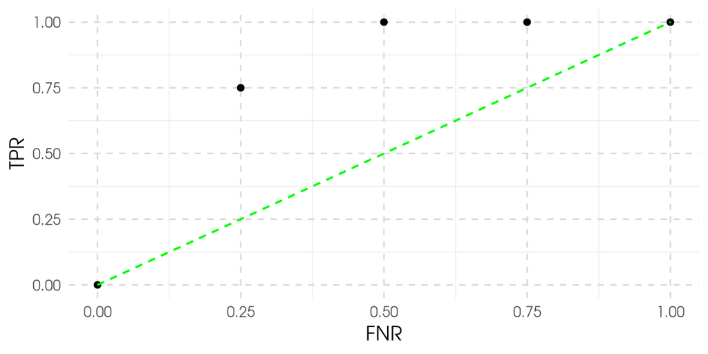

## AUC - ROC curve

- Let’s say we define our threshold as \(0.7\);

|  | Actual positive | Actual negative |
| --- | --- | --- |
| positive | 3 | 0 |
| negative | 1 | 4 |

\[ \text{TPR} = \frac{3}{3 + 1} = 0.75 \] \[ \text{FNR} = \frac{0}{0 + 4} = 0 \]

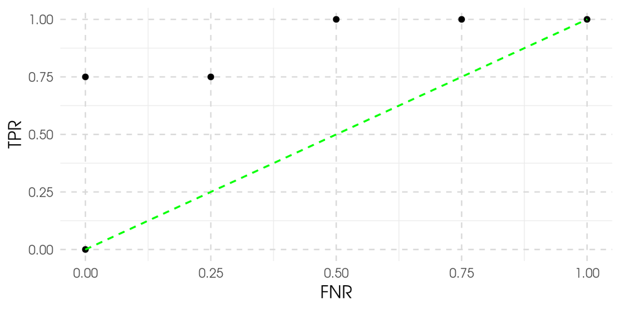

## AUC - ROC curve

- If we continue increasing the threshold:

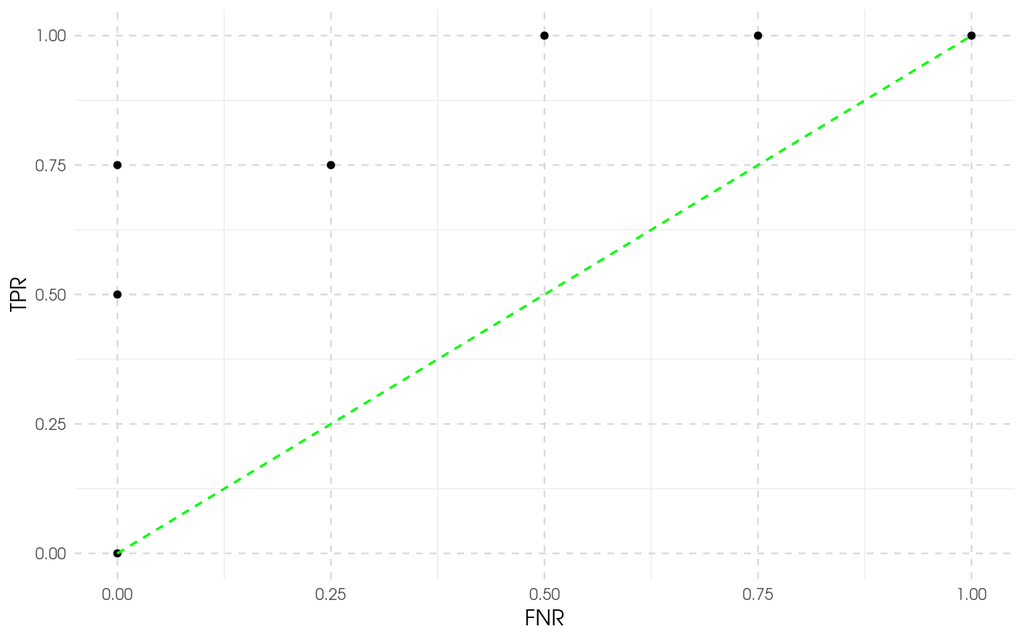

## AUC - ROC curve

- If we continue increase the threshold:

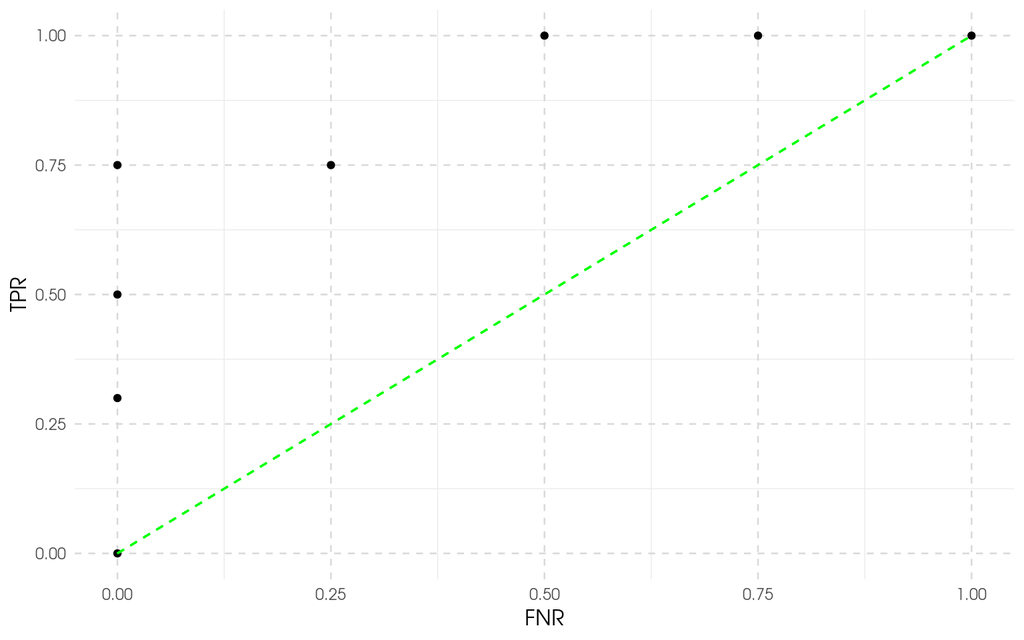

## AUC - ROC curve

- If connect the dots:

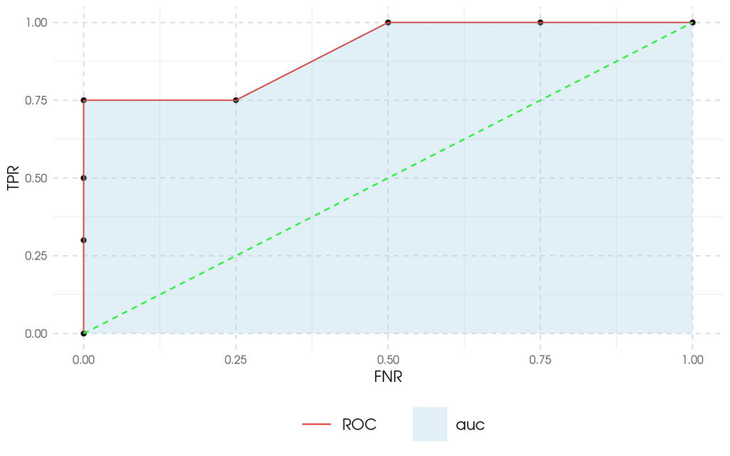

## AUC - ROC curve

- **AUC** makes it easy to compare one **ROC** curve to another:

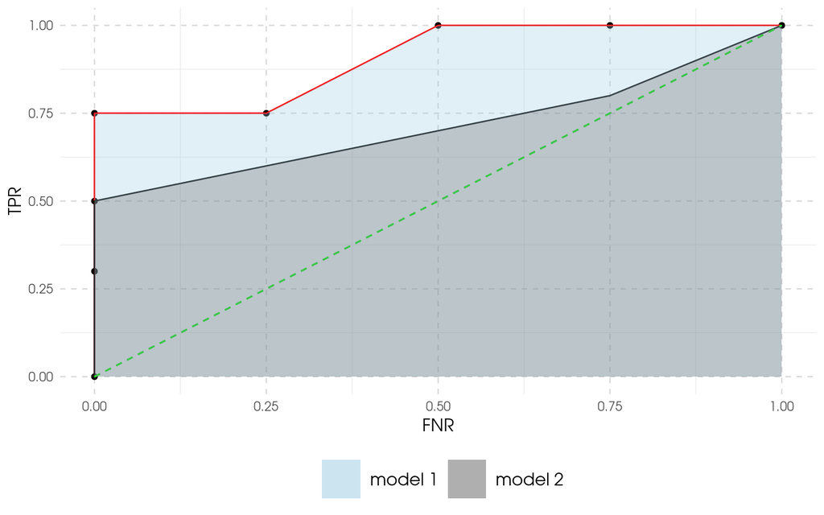

## AUC - ROC curve

- **Receiver Operating Characteristic (ROC)** is the most commonly used way to visualize the performance of a binary classifier;
- AUC is (arguably) the best way to summarize its performance in a single number.
- ROC curve is used to examine the trade-off of true and false positives;
- It tells how much model is capable of distinguishing between classes;
- Higher the **AUC**, better the model is at predicting 0s as 0s and 1s as 1s;

## LogLoss

- **Logarithm Loss** is a classification *loss function* commonly used as *evaluation metric*;
- **LogLoss** quantifies the accuracy of a classifier by **highly penalising false classifications**;
- In order to calculate *LogLoss* the classifier must assign a probability to each class;
- Minimising the *LogLoss* is equivalent to maximising the accuracy of the classifier;
- Mathematically LogLoss is defined as

\[ -\frac{1}{N} \sum_{i=1}^N \sum_{k = 1}^K y_{ik} \log p_{ik} \] where:

- \(N\) is the number of samples;
- \(K\) is the number of classes;
- \(y_{ik}\) is a binary indicator of wheter \(y_{ik}\) is correctly classified;
- \(p_{ik}\) is the model probability.

## LogLoss

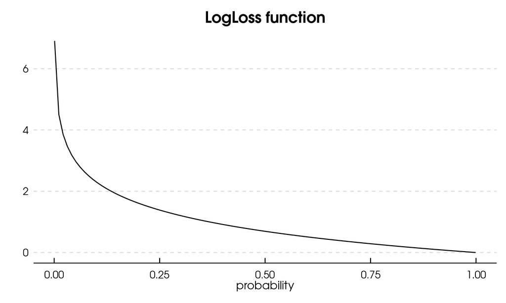

## Estimating Future Performance

## Resampling Methods

- **Resampling methods** are indispensable tool;
- They involve repeatedly drawing sample from a training set and refitting a model on each sample;
- Resampling methods can be computationall expensive;
- We will discuss the most commonly used resampling approaches:
  - *Holdout method*;
  - *Cross-validation method*;
- All of these techniques can be used to estimate the **test error**;

## Holdout Method

- In general, (almost) **do not** care about training performance;
- Performance on unseen data;
- **Problem**: unseen data is **unseen**;
- The most simple approach to estimate future performance: **holdout method**;
- Involves **randomly** dividing the available set into two parts:
  1. *training set*;
  2. *validation set*;

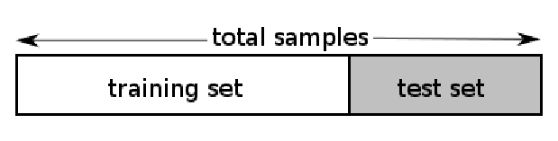

- The model is fit on *training set* and the prediction is made on *validation set*;
- The resulting *validation* performance provides an estimate of future performance;

## Holdout Method

- Holdout method is conceptually simple;
- Easy to implement;
- However, it has two potential drawbacks:
  1. The *validation* estimate of the test error can be highly variable;
  2. The *validation* estimate may tend to **overestimate** the future performance;

## Cross Validation Method

- **Cross-validation** is another resampling method used to estimate the future performance;
- It involves splitting the dataset into \(K\) different *folders*;
- Hold the folder \(k\) as a *validation* set;
- Use \(K-1\) folders as training set to fit the model;
- Make prediction on the \(k\) folder;
- Repeat the process for each \(k\), where \(k = 1, 2, ..., K\);
- In the end, we will have a set of \(K\) performance;

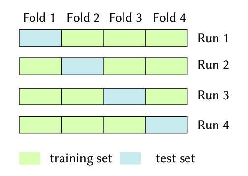

## Cross Validation Method

- The final estimate for future performance will be the average of \(K\) metrics;
- CV method has demonstrated exccelent estimates for future performance;
- But not only to estimate future performance can CV be used;
- Also, choose **tunning parameters**;

[output not shown]

## Wrapup

**Any questions**?

## Time to Code!

## Economics Applications

## Source of Economic Growth: Barro and Lee (1994) revisited

- Growth rates vary enormously across countries over long periods of time;
- For 116 countries from 1965 to 1985;
- The lowest quintile had an average growth rate of real per capita GDP of \(-1.3\%\);
- The highest quintile had an average of \(4.8\%\);
- The key challenge for economists is to understand why growth outcomes differ so much;
- build on previous cross-country empirical analyses to isolate major determinants of growth rates;

## Source of Economic Growth: Barro and Lee (1994) revisited

- They describe in terms of five key determinants of growth:
1. **Conditional convergence effect** (real per-capita GDP relative to its initial level of human capital);
2. **high ratio of investment to GDP**;
3. **Large government** (ratio of government consumption to GDP);
4. **Government-induced distortions of markets** (black-market premium on foreign exchange);
5. **Political instability** (propensity toward revolutions).
- What if we had a method in which we extract what is important in a data-driven way?
- **LASSO**;

## Can Machine Learning Help Predict the Outcome of Asylum Adjudications?

### Chen and Eagel, Computational Analysis of Law, Forthcoming

- They analyzed almost \(500K\) *asylum hearings* from 336 different hearing locations;
- Rendered by 441 unique judges over a thirty-two year period from 1981-2013;
- The problem of **asylum adjudication** is a binary classification problem;
- Using **Random Forest**, we predict twenty-seven years of refugee decisions.
- Using only data available up to the decision date, they correctly classifies \(82\%\);

## Can Machine Learning Help Predict the Outcome of Asylum Adjudications?

### Chen and Eagel, Computational Analysis of Law, Forthcoming

- Results:
  - Decision makers exhibit a fair degree of autocorrelation in their rulings;
  - Extraneous factors such as, news and the local weather may be impacting the fate of an asylum seeker;
  - Surprisingly, granting asylum is predominantly driven by trend features and judicial characteristics- features;
  - one third-driven by case information, news events, and court information;

## Can Machine Learning Help Predict the Outcome of Asylum Adjudications?

### Chen and Eagel, Computational Analysis of Law, Forthcoming

- An individual may apply for refugee status in the United States either *affirmatively* or *defensively*.
- Dataset contained approximately five hundred thousand cases and 137 features.
- classified each feature into one of six buckets:
1. **case information** (number of family members, date of hearing, and whether the application was affirmative or defensive);
2. **judge information** (law school graduation year, gender, President, military);
3. **court information** (number of hearings per day, historical factors);
4. **trend** (historical factors);
5. **weather** (NOAA);
6. **news** (media coverage may weigh on a justice’s consciousness when ruling);

## Can Machine Learning Help Predict the Outcome of Asylum Adjudications?

### Chen and Eagel, Computational Analysis of Law, Forthcoming

- Predictive Model:
  - Trained the algorithm on all asylum cases up to December 31st of the prior calendar year;
  - Use the trained model to make predictions on all the incoming cases for the following twelve months.

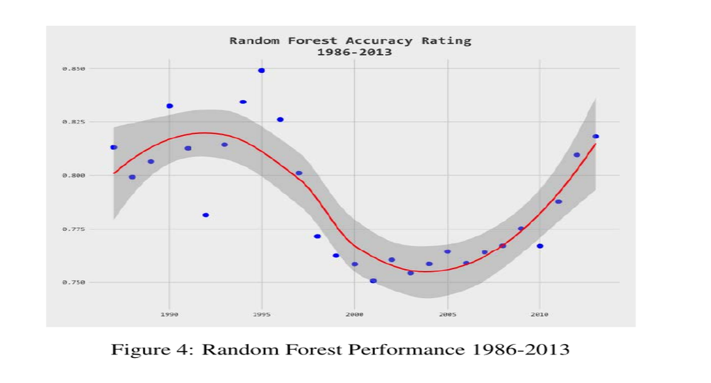

## Can Machine Learning Help Predict the Outcome of Asylum Adjudications?

### Chen and Eagel, Computational Analysis of Law, Forthcoming

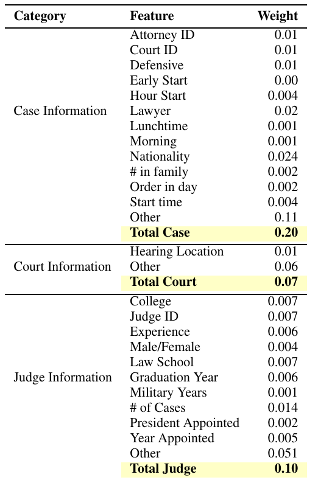

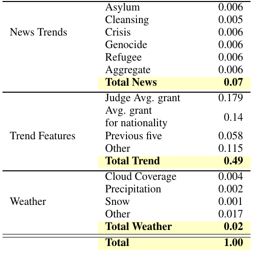

Other interesting papers:

- Kleinberg et al (2017). **Human Decisions and Machine Predictions**, *NBER Working Paper Series*;
- Erel et al (2018). **Selecting Directors using Machine Learning**, *NBER Working Paper Series*;
- Chen et al (2019). **What Matters: Agreement between U.S. Courts of Appeals Judges**, *Journal of Machine Learning Research, 2019, forthcoming*;
- What is the main objective of *causal inference*?
  - To draw useful knowledge from the data \(\rightarrow\) how Yx and a **certain** X are related;
  - Regression Methods;
- Some models can be used to extract causal interpretations:
  1. *Instrumental Variables*;
  2. *Differences-in-differences*;
  3. *Regression discontinuity designs*;
  4. *Synthetic Control*;

However…

- High-Dimensional Data has become increasingly natural;
- Consequently… Some issues must be taken into account.

In this paper: **LASSO + IV**;

## Estimating the Effect of Institutions on Output

### Acemoglu at al (2001) revisited

- Consider the estimation of the effect of institutions on aggregate output following the work of Acemoglu et al. (2001);
- E mploy an IV method and argue for the use of mortality rates for early European settlers as an **IV** for Institution;
- A potential candidate for such factor is geography. Hence, the authors control for the distance from the equator (latitude).
- Formally, their IV model can be represented as

\[ Y_t = \mu + \alpha R_t + X'_t \beta + \epsilon_t \\ R_t = \zeta + \gamma \log(M_t) + X'\eta + \upsilon_t\\ \]

- where
  - Y is a measure of country’s output;
  - R is a measure of institution,
  - M is the mortality rate for early settlers, and
  - X is the matrix with geography control variable.
- The data set contain information on 64 countries;
- The geography information is composed by: latitude and dummies for continents;
- It is implicitly assumed that the confounding effect of geography is properly captured by a linear term in latitude;
- The use of high-dimensional method could allow us to alleviate this assumption.
- The set of variables considered are the same as in Acemoglu et al. (2001);
- With additional non-linear terms for latitude:
  - Dummies for Africa, Asia, North America and South America;
  - Cubic-spline in latitude with three knots;
- To make use of this enhanced X, note that the model is equivalent to the three-system:

\[ Y_t = \mu + \alpha R + X'\beta + \epsilon \\ R_t = \pi_1 log(M) + X'\Pi_2 + v_t \\ log(M_t) = X'_t\gamma + u_t \]

- which yields three reduced form equations:

\[ Y_t = X'\tilde{\beta} + \tilde{\epsilon}_t \\ R_t = X'_t\tilde{\Pi}_2 + \tilde{u}_t \\ log(M_t) = X'_t{\gamma} + u_i \]

- Thus, select a set of control features by carrying out variable selection;
- After selecting the columns of X, valid estimation and inference can be estimated using **IV**;

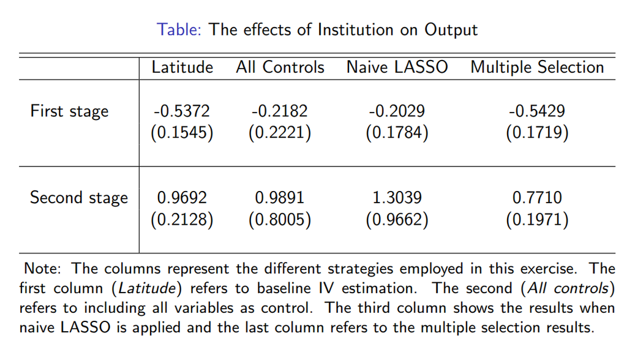

## Finally…

**Any questions**?